# chicago_case_study_q1_answers

E2

2026-01-14

# **Case Study: Cyclist Bike Share Quarter one**

## 1. ASK

**Business Task**: Determine how annual members and casual riders use cyclist differently. - Why would casual riders buy Cyclist annual memberships? - How can Cyclist use digital media to influence casual riders to become members?  
**Goal**: To gain insights that will help the marketing team design strategies to convert casual riders into annual members, as members are considered more profitable for the company’s future growth  
**Stakeholders**:  
- **Lily Moreno**: Marketing Director who manages the marketing analytics team.  
- **Marketing Analytics Team**: Me and my colleagues who collect and analyse data to support decision making.  
-**Executive Team**: The decision makers, who use the results of the marketing analytics team to guide their final decisions.  
-**Users/Cyclist/Rider**: Divided into **annual members** also referred to as **Subscribers** who pay a subscription,  
and **casual riders** also referred to as **Customers** who pay once off.

## 2. Prepare

This data was made publicly available by Motivate International Inc.  
-**Data Integrity**: This data does not include Personal Identifiable Information like Identity numbers or credit card numbers, so users privacy is protected.  
- **Data location**: Clik this link to [download the dataset](https://divvy-tripdata.s3.amazonaws.com/Divvy_Trips_2019_Q1.zip)  
- **Data Organization**: the data is organised as a .zip file Divvy_Trips_2019_Q1.zip which contain data stored in .csv format.  
-**Tool Selection**: I choose to use r, since it can handle large datasets, create visuals and reproducible results.

## 3. Process

### Setting up the environment

```r
library(tidyverse)
bikeshare_trips_2019_q1 <-
  read_csv("datasets/divy_trips_12_months/chiacago_raw_data/Divvy_Trips_2019_Q1/Divvy_Trips_2019_Q1.csv")
```

### View and Rename columns

```r
print("Here is a list of the column names:")
```

```
## [1] "Here is a list of the column names:"
```

```r
colnames(bikeshare_trips_2019_q1)
```

```
##  [1] "trip_id"           "start_time"        "end_time"
##  [4] "bikeid"            "tripduration"      "from_station_id"
##  [7] "from_station_name" "to_station_id"     "to_station_name"
## [10] "usertype"          "gender"            "birthyear"
```

```r
bikeshare_trips_2019_q1 <- bikeshare_trips_2019_q1 %>%
  rename(
    stop_time = end_time,
    bike_id = bikeid,
    trip_duration = tripduration,
    user_type = usertype,
    birth_year = birthyear)
print("Five columns have been renamed here are the current column names:")
```

```
## [1] "Five columns have been renamed here are the current column names:"
```

```r
colnames(bikeshare_trips_2019_q1)
```

```
##  [1] "trip_id"           "start_time"        "stop_time"
##  [4] "bike_id"           "trip_duration"     "from_station_id"
##  [7] "from_station_name" "to_station_id"     "to_station_name"
## [10] "user_type"         "gender"            "birth_year"
```

### Create a ride length column

```r
bikeshare_trips_2019_q1 <- bikeshare_trips_2019_q1 %>%
  mutate(ride_length = stop_time - start_time)
print("Here is the structure of our tibble with the new ride_length column added:")
```

```
## [1] "Here is the structure of our tibble with the new ride_length column added:"
```

```r
glimpse(bikeshare_trips_2019_q1)
```

```
## Rows: 365,069
## Columns: 13
## $ trip_id           <dbl> 21742443, 21742444, 21742445, 21742446, 21742447, 21…
## $ start_time        <dttm> 2019-01-01 00:04:37, 2019-01-01 00:08:13, 2019-01-0…
## $ stop_time         <dttm> 2019-01-01 00:11:07, 2019-01-01 00:15:34, 2019-01-0…
## $ bike_id           <dbl> 2167, 4386, 1524, 252, 1170, 2437, 2708, 2796, 6205,…
## $ trip_duration     <dbl> 390, 441, 829, 1783, 364, 216, 177, 100, 1727, 336, …
## $ from_station_id   <dbl> 199, 44, 15, 123, 173, 98, 98, 211, 150, 268, 299, 2…
## $ from_station_name <chr> "Wabash Ave & Grand Ave", "State St & Randolph St", …
## $ to_station_id     <dbl> 84, 624, 644, 176, 35, 49, 49, 142, 148, 141, 295, 4…
## $ to_station_name   <chr> "Milwaukee Ave & Grand Ave", "Dearborn St & Van Bure…
## $ user_type         <chr> "Subscriber", "Subscriber", "Subscriber", "Subscribe…
## $ gender            <chr> "Male", "Female", "Female", "Male", "Male", "Female"…
## $ birth_year        <dbl> 1989, 1990, 1994, 1993, 1994, 1983, 1984, 1990, 1995…
## $ ride_length       <drtn> 6.500000 mins, 7.350000 mins, 13.816667 mins, 29.71…
```

### Convert ride length to numeric

ride length: is stored in minutes we will convert it to numeric for use in calculations

```r
bikeshare_trips_2019_q1$ride_length <- as.numeric(as.character(bikeshare_trips_2019_q1$ride_length))
print("Here is the structure of our tibble with the ride_length column converted to numeric:")
```

```
## [1] "Here is the structure of our tibble with the ride_length column converted to numeric:"
```

```r
glimpse(bikeshare_trips_2019_q1)
```

```
## Rows: 365,069
## Columns: 13
## $ trip_id           <dbl> 21742443, 21742444, 21742445, 21742446, 21742447, 21…
## $ start_time        <dttm> 2019-01-01 00:04:37, 2019-01-01 00:08:13, 2019-01-0…
## $ stop_time         <dttm> 2019-01-01 00:11:07, 2019-01-01 00:15:34, 2019-01-0…
## $ bike_id           <dbl> 2167, 4386, 1524, 252, 1170, 2437, 2708, 2796, 6205,…
## $ trip_duration     <dbl> 390, 441, 829, 1783, 364, 216, 177, 100, 1727, 336, …
## $ from_station_id   <dbl> 199, 44, 15, 123, 173, 98, 98, 211, 150, 268, 299, 2…
## $ from_station_name <chr> "Wabash Ave & Grand Ave", "State St & Randolph St", …
## $ to_station_id     <dbl> 84, 624, 644, 176, 35, 49, 49, 142, 148, 141, 295, 4…
## $ to_station_name   <chr> "Milwaukee Ave & Grand Ave", "Dearborn St & Van Bure…
## $ user_type         <chr> "Subscriber", "Subscriber", "Subscriber", "Subscribe…
## $ gender            <chr> "Male", "Female", "Female", "Male", "Male", "Female"…
## $ birth_year        <dbl> 1989, 1990, 1994, 1993, 1994, 1983, 1984, 1990, 1995…
## $ ride_length       <dbl> 6.500000, 7.350000, 13.816667, 29.716667, 6.066667, …
```

### Create a column to store Day of the week

```r
bikeshare_trips_2019_q1 <- bikeshare_trips_2019_q1 %>%
  mutate( week_day = wday(start_time, label = TRUE, abbr = FALSE))
print("Here are the structure of our tibble with the week_day column added:")
```

```
## [1] "Here are the structure of our tibble with the week_day column added:"
```

```r
glimpse(bikeshare_trips_2019_q1)
```

```
## Rows: 365,069
## Columns: 14
## $ trip_id           <dbl> 21742443, 21742444, 21742445, 21742446, 21742447, 21…
## $ start_time        <dttm> 2019-01-01 00:04:37, 2019-01-01 00:08:13, 2019-01-0…
## $ stop_time         <dttm> 2019-01-01 00:11:07, 2019-01-01 00:15:34, 2019-01-0…
## $ bike_id           <dbl> 2167, 4386, 1524, 252, 1170, 2437, 2708, 2796, 6205,…
## $ trip_duration     <dbl> 390, 441, 829, 1783, 364, 216, 177, 100, 1727, 336, …
## $ from_station_id   <dbl> 199, 44, 15, 123, 173, 98, 98, 211, 150, 268, 299, 2…
## $ from_station_name <chr> "Wabash Ave & Grand Ave", "State St & Randolph St", …
## $ to_station_id     <dbl> 84, 624, 644, 176, 35, 49, 49, 142, 148, 141, 295, 4…
## $ to_station_name   <chr> "Milwaukee Ave & Grand Ave", "Dearborn St & Van Bure…
## $ user_type         <chr> "Subscriber", "Subscriber", "Subscriber", "Subscribe…
## $ gender            <chr> "Male", "Female", "Female", "Male", "Male", "Female"…
## $ birth_year        <dbl> 1989, 1990, 1994, 1993, 1994, 1983, 1984, 1990, 1995…
## $ ride_length       <dbl> 6.500000, 7.350000, 13.816667, 29.716667, 6.066667, …
## $ week_day          <ord> Tuesday, Tuesday, Tuesday, Tuesday, Tuesday, Tuesday…
```

### Remove negative ride_length

```r
bikeshare_trips_2019_q1 <- bikeshare_trips_2019_q1 %>%
  filter(ride_length > 0)
print("Here are the structure of our tibble with the negative values from the ride_length removed:")
```

```
## [1] "Here are the structure of our tibble with the negative values from the ride_length removed:"
```

```r
glimpse(bikeshare_trips_2019_q1)
```

```
## Rows: 365,069
## Columns: 14
## $ trip_id           <dbl> 21742443, 21742444, 21742445, 21742446, 21742447, 21…
## $ start_time        <dttm> 2019-01-01 00:04:37, 2019-01-01 00:08:13, 2019-01-0…
## $ stop_time         <dttm> 2019-01-01 00:11:07, 2019-01-01 00:15:34, 2019-01-0…
## $ bike_id           <dbl> 2167, 4386, 1524, 252, 1170, 2437, 2708, 2796, 6205,…
## $ trip_duration     <dbl> 390, 441, 829, 1783, 364, 216, 177, 100, 1727, 336, …
## $ from_station_id   <dbl> 199, 44, 15, 123, 173, 98, 98, 211, 150, 268, 299, 2…
## $ from_station_name <chr> "Wabash Ave & Grand Ave", "State St & Randolph St", …
## $ to_station_id     <dbl> 84, 624, 644, 176, 35, 49, 49, 142, 148, 141, 295, 4…
## $ to_station_name   <chr> "Milwaukee Ave & Grand Ave", "Dearborn St & Van Bure…
## $ user_type         <chr> "Subscriber", "Subscriber", "Subscriber", "Subscribe…
## $ gender            <chr> "Male", "Female", "Female", "Male", "Male", "Female"…
## $ birth_year        <dbl> 1989, 1990, 1994, 1993, 1994, 1983, 1984, 1990, 1995…
## $ ride_length       <dbl> 6.500000, 7.350000, 13.816667, 29.716667, 6.066667, …
## $ week_day          <ord> Tuesday, Tuesday, Tuesday, Tuesday, Tuesday, Tuesday…
```

### Check for duplicates

```r
num_duplicates <- sum(duplicated(bikeshare_trips_2019_q1))
num_duplicates
```

```
## [1] 0
```

## 4.Analyse

### Get a statistical summary of the entire tibble

```r
summary(bikeshare_trips_2019_q1)
```

```
##     trip_id           start_time                    stop_time
##  Min.   :21742443   Min.   :2019-01-01 00:04:37   Min.   :2019-01-01 00:11:07
##  1st Qu.:21848765   1st Qu.:2019-01-23 05:26:54   1st Qu.:2019-01-23 05:49:40
##  Median :21961829   Median :2019-02-25 07:52:56   Median :2019-02-25 08:03:50
##  Mean   :21960872   Mean   :2019-02-19 21:43:15   Mean   :2019-02-19 22:00:11
##  3rd Qu.:22071823   3rd Qu.:2019-03-17 16:52:47   3rd Qu.:2019-03-17 17:16:16
##  Max.   :22178528   Max.   :2019-03-31 23:53:48   Max.   :2019-06-17 16:04:35
##
##     bike_id     trip_duration      from_station_id from_station_name
##  Min.   :   1   Min.   :      61   Min.   :  2.0   Length:365069
##  1st Qu.:1777   1st Qu.:     326   1st Qu.: 76.0   Class :character
##  Median :3489   Median :     524   Median :170.0   Mode  :character
##  Mean   :3429   Mean   :    1016   Mean   :198.1
##  3rd Qu.:5157   3rd Qu.:     866   3rd Qu.:287.0
##  Max.   :6471   Max.   :10628400   Max.   :665.0
##
##  to_station_id   to_station_name     user_type            gender
##  Min.   :  2.0   Length:365069      Length:365069      Length:365069
##  1st Qu.: 76.0   Class :character   Class :character   Class :character
##  Median :168.0   Mode  :character   Mode  :character   Mode  :character
##  Mean   :198.6
##  3rd Qu.:287.0
##  Max.   :665.0
##
##    birth_year     ride_length             week_day
##  Min.   :1900    Min.   :1.017e+00   Sunday   :27999
##  1st Qu.:1975    1st Qu.:5.433e+00   Monday   :50399
##  Median :1985    Median :8.733e+00   Tuesday  :61005
##  Mean   :1982    Mean   :1.694e+01   Wednesday:60414
##  3rd Qu.:1990    3rd Qu.:1.443e+01   Thursday :66903
##  Max.   :2003    Max.   :1.772e+05   Friday   :63047
##  NA's   :18023                       Saturday :35302
```

### Get a statistical summary of the ride length column

```r
summary(bikeshare_trips_2019_q1$ride_length)
```

```
##      Min.   1st Qu.    Median      Mean   3rd Qu.      Max.
## 1.017e+00 5.433e+00 8.733e+00 1.694e+01 1.443e+01 1.772e+05
```

### Compare ride length between annual members and casual riders

```r
bikeshare_trips_2019_q1 %>%
  group_by(user_type) %>%
  summarise(average_ride = mean(ride_length))
```

```
## # A tibble: 2 × 2
##   user_type  average_ride
##   <chr>             <dbl>
## 1 Customer           61.9
## 2 Subscriber         13.9
```

```r
# aggregate(bikeshare_trips_2019_q1$ride_length ~ bikeshare_trips_2019_q1$user_type, FUN = mean)
```

### See the average ride time by each day for annual members vs casual users

```r
bikeshare_trips_2019_q1 %>%
  group_by(user_type, week_day) %>%
  summarize(average_ride = mean(ride_length))
```

```
## # A tibble: 14 × 3
## # Groups:   user_type [2]
##    user_type  week_day  average_ride
##    <chr>      <ord>            <dbl>
##  1 Customer   Sunday            41.6
##  2 Customer   Monday            44.5
##  3 Customer   Tuesday           40.5
##  4 Customer   Wednesday         52.0
##  5 Customer   Thursday         134.
##  6 Customer   Friday            59.9
##  7 Customer   Saturday          60.3
##  8 Subscriber Sunday            16.8
##  9 Subscriber Monday            14.6
## 10 Subscriber Tuesday           14.4
## 11 Subscriber Wednesday         12.1
## 12 Subscriber Thursday          12.0
## 13 Subscriber Friday            13.9
## 14 Subscriber Saturday          17.0
```

```r
# aggregate(q1_2019_v2$ride_length ~ q1_2019_v2$user_type + q1_2019_v2$day_of_week, FUN = mean)
```

### See the number of rides and average ride time by each day for annual members vs casual users

```r
bikeshare_trips_2019_q1 %>%
  group_by(user_type, week_day) %>%
  summarise(number_of_rides = n(), average_duration = mean(ride_length)) %>%
  arrange(user_type, week_day)
```

```
## # A tibble: 14 × 4
## # Groups:   user_type [2]
##    user_type  week_day  number_of_rides average_duration
##    <chr>      <ord>               <int>            <dbl>
##  1 Customer   Sunday               3766             41.6
##  2 Customer   Monday               1892             44.5
##  3 Customer   Tuesday              2728             40.5
##  4 Customer   Wednesday            2489             52.0
##  5 Customer   Thursday             2920            134.
##  6 Customer   Friday               3375             59.9
##  7 Customer   Saturday             5993             60.3
##  8 Subscriber Sunday              24233             16.8
##  9 Subscriber Monday              48507             14.6
## 10 Subscriber Tuesday             58277             14.4
## 11 Subscriber Wednesday           57925             12.1
## 12 Subscriber Thursday            63983             12.0
## 13 Subscriber Friday              59672             13.9
## 14 Subscriber Saturday            29309             17.0
```

## 5.Share

### Visualise percentage of rides by user type

```r
total_rides_q1 <- bikeshare_trips_2019_q1 %>%
  summarise(total = n()) %>%
  pull(total)
total_rides_q1
```

```
## [1] 365069
```

```r
rides_by_user_type <- bikeshare_trips_2019_q1 %>%
  count(user_type, sort = TRUE)
rides_by_user_type
```

```
## # A tibble: 2 × 2
##   user_type       n
##   <chr>       <int>
## 1 Subscriber 341906
## 2 Customer    23163
```

```r
percentage_rides_by_user_type <- rides_by_user_type %>%
  mutate(percentage_trips = n / total_rides_q1 * 100)
percentage_rides_by_user_type <- percentage_rides_by_user_type %>%
  select(-n)
percentage_rides_by_user_type
```

```
## # A tibble: 2 × 2
##   user_type  percentage_trips
##   <chr>                 <dbl>
## 1 Subscriber            93.7
## 2 Customer               6.34
```

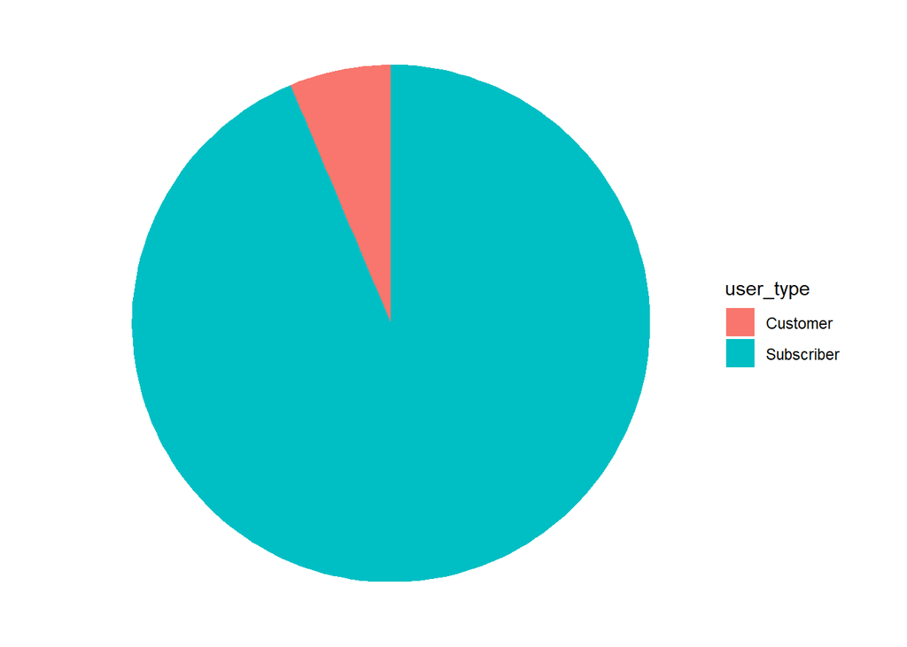

```r
ggplot(data = percentage_rides_by_user_type, mapping = aes(x = "",y = percentage_trips, fill = user_type)) +
  geom_bar(stat = "identity", width = 1) +
  coord_polar("y", start = 0) +
  theme_void()
```

### Visualise number of rides by user type for each week day

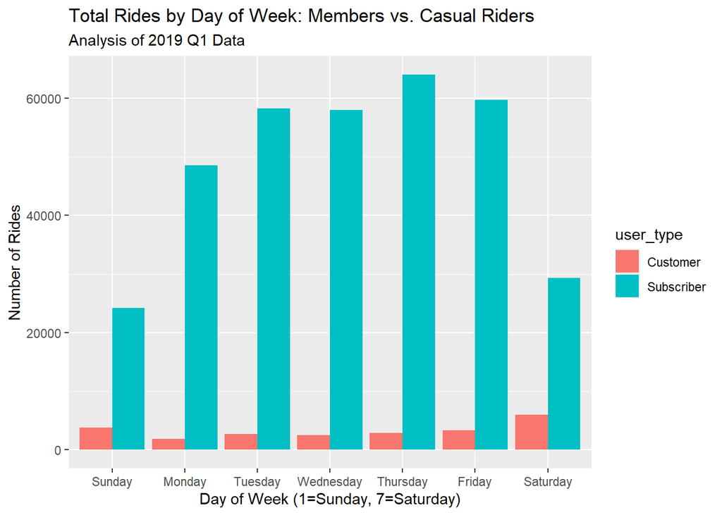

```r
bikeshare_trips_2019_q1 %>%
  group_by(user_type, week_day) %>%
  summarise(number_of_rides = n()) %>%
  ggplot(aes(x = week_day, y = number_of_rides, fill = user_type)) +
  geom_col(position = "dodge") +
  labs(title = "Total Rides by Day of Week: Members vs. Casual Riders",
       subtitle = "Analysis of 2019 Q1 Data",
       x = "Day of Week (1=Sunday, 7=Saturday)",
       y = "Number of Rides")
```